# Taller 3: Manipulación de datos en R

Uso Avanzado de Sistemas de Información Geográfica

Autor/a

Afiliación

Dr. Francisco Zambrano

Escuela de Ingeniería en Medio Ambiente, Universidad Mayor

Fecha de publicación

16 de septiembre de 2024

# 1 ¿Qué debe entregar?

Debeŕá utilizar RStudio para crear un script, en donde resolverá cada uno de los ejercicios. Debe utilizar los comentarios (#) para la descripción del ejercicio e incorporar cualquier texto que ayude a entender lo realizado. A modo de ejemplo:

**Código**

```r
Código

# Ejercicio 1:
# comentario explicando lo que se hace

  Aca va el script que resuelve el ejericio 1
```

# 2 Datos

Descargar desde [acá](https://drive.google.com/drive/folders/1E64SJ7syM-OGk1PkAmB2QmWfJkwgyXc8?usp=sharing)

# 3 Ejercicios:

1- Cargue cada uno de los archivos delimitados por coma (.csv) en un objeto en R con el nombre del archivo sin considerar la extensión (.csv)

**Código**

```r
paises <- read.csv2('../data/paises.csv')
atmosfera <- read.csv2('../data/atmosfera.csv')
aviones <- read.csv2('../data/clima.csv')
clima <- read.csv2('../data/clima.csv')
```

2- ¿A qué tipo de estructura de datos corresponde cada uno de los objetos?

**Código**

```r
class(paises)
```

```
[1] "data.frame"
```

**Código**

```r
class(atmosfera)
```

```
[1] "data.frame"
```

**Código**

```r
class(aviones)
```

```
[1] "data.frame"
```

**Código**

```r
class(clima)
```

```
[1] "data.frame"
```

3- ¿Cuántas variables y observaciones tiene cada uno de los objetos?

**Código**

```r
#variables
ncol(paises)
```

```
[1] 6
```

**Código**

```r
ncol(atmosfera)
```

```
[1] 11
```

**Código**

```r
ncol(aviones)
```

```
[1] 15
```

**Código**

```r
ncol(clima)
```

```
[1] 15
```

**Código**

```r
#observaciones
nrow(paises)
```

```
[1] 1704
```

**Código**

```r
nrow(atmosfera)
```

```
[1] 41472
```

**Código**

```r
nrow(aviones)
```

```
[1] 26115
```

**Código**

```r
nrow(clima)
```

```
[1] 26115
```

4- ¿A qué tipo de datos corresponde cada una de las variables en cada objeto?

**Código**

```r
str(paises)
```

```
'data.frame':   1704 obs. of  6 variables:
 $ pais             : chr  "Afganistán" "Afganistán" "Afganistán" "Afganistán" ...
 $ continente       : chr  "Asia" "Asia" "Asia" "Asia" ...
 $ anio             : int  1952 1957 1962 1967 1972 1977 1982 1987 1992 1997 ...
 $ esperanza_de_vida: num  28.8 30.3 32 34 36.1 ...
 $ poblacion        : int  8425333 9240934 10267083 11537966 13079460 14880372 12881816 13867957 16317921 22227415 ...
 $ pib_per_capita   : num  779 821 853 836 740 ...
```

**Código**

```r
str(atmosfera)
```

```
'data.frame':   41472 obs. of  11 variables:
 $ latitud        : num  36.2 33.7 31.2 28.7 26.2 ...
 $ longitud       : num  -114 -114 -114 -114 -114 ...
 $ anio           : int  1995 1995 1995 1995 1995 1995 1995 1995 1995 1995 ...
 $ mes            : int  1 1 1 1 1 1 1 1 1 1 ...
 $ temp_superficie: num  273 280 285 289 292 ...
 $ temperatura    : num  272 282 285 291 293 ...
 $ presion        : int  835 940 960 990 1000 1000 1000 1000 1000 1000 ...
 $ ozono          : int  304 304 298 276 274 264 258 252 250 250 ...
 $ nube_baja      : num  7.5 11.5 16.5 20.5 26 30 29.5 26.5 27.5 26 ...
 $ nube_media     : num  34.5 32.5 26 14.5 10.5 9.5 11 17.5 18.5 16.5 ...
 $ nube_alta      : num  26 20 16 13 7.5 8 14.5 19.5 22.5 21 ...
```

**Código**

```r
str(aviones)
```

```
'data.frame':   26115 obs. of  15 variables:
 $ origen          : chr  "EWR" "EWR" "EWR" "EWR" ...
 $ anio            : int  2013 2013 2013 2013 2013 2013 2013 2013 2013 2013 ...
 $ mes             : int  1 1 1 1 1 1 1 1 1 1 ...
 $ dia             : int  1 1 1 1 1 1 1 1 1 1 ...
 $ hora            : int  1 2 3 4 5 6 7 8 9 10 ...
 $ temperatura     : num  39 39 39 39.9 39 ...
 $ punto_rocio     : num  26.1 27 28 28 28 ...
 $ humedad         : num  59.4 61.6 64.4 62.2 64.4 ...
 $ direccion_viento: int  270 250 240 250 260 240 240 250 260 260 ...
 $ velocidad_viento: num  10.36 8.06 11.51 12.66 12.66 ...
 $ velocidad_rafaga: num  NA NA NA NA NA NA NA NA NA NA ...
 $ precipitacion   : num  0 0 0 0 0 0 0 0 0 0 ...
 $ presion         : num  1012 1012 1012 1012 1012 ...
 $ visibilidad     : num  10 10 10 10 10 10 10 10 10 10 ...
 $ fecha_hora      : chr  "2013-01-01T06:00:00Z" "2013-01-01T07:00:00Z" "2013-01-01T08:00:00Z" "2013-01-01T09:00:00Z" ...
```

**Código**

```r
str(clima)
```

```
'data.frame':   26115 obs. of  15 variables:
 $ origen          : chr  "EWR" "EWR" "EWR" "EWR" ...
 $ anio            : int  2013 2013 2013 2013 2013 2013 2013 2013 2013 2013 ...
 $ mes             : int  1 1 1 1 1 1 1 1 1 1 ...
 $ dia             : int  1 1 1 1 1 1 1 1 1 1 ...
 $ hora            : int  1 2 3 4 5 6 7 8 9 10 ...
 $ temperatura     : num  39 39 39 39.9 39 ...
 $ punto_rocio     : num  26.1 27 28 28 28 ...
 $ humedad         : num  59.4 61.6 64.4 62.2 64.4 ...
 $ direccion_viento: int  270 250 240 250 260 240 240 250 260 260 ...
 $ velocidad_viento: num  10.36 8.06 11.51 12.66 12.66 ...
 $ velocidad_rafaga: num  NA NA NA NA NA NA NA NA NA NA ...
 $ precipitacion   : num  0 0 0 0 0 0 0 0 0 0 ...
 $ presion         : num  1012 1012 1012 1012 1012 ...
 $ visibilidad     : num  10 10 10 10 10 10 10 10 10 10 ...
 $ fecha_hora      : chr  "2013-01-01T06:00:00Z" "2013-01-01T07:00:00Z" "2013-01-01T08:00:00Z" "2013-01-01T09:00:00Z" ...
```

5- Respecto al objeto “paises”, utilizando indexación seleccione sólo las observaciones que corresponden al país de Chile. Guarde el resultado en el objeto “paises_chile”.

**Código**

```r
#forma 1
paises_chile <- paises[paises$pais == 'Chile',]

#forma 2
paises_chile2 <- subset(paises,pais == 'Chile')

#comprueba si son lo mismo

identical(paises_chile,paises_chile2)
```

```
[1] TRUE
```

6- Respecto al objeto “paises_chile”, haga un gráfico de puntos y lineas en donde se pueda visualizar la variación de la esperanza de vida a través de los años. Los títulos de los ejes debe corresponder a “años” y “esperanza de vida”.-

**Código**

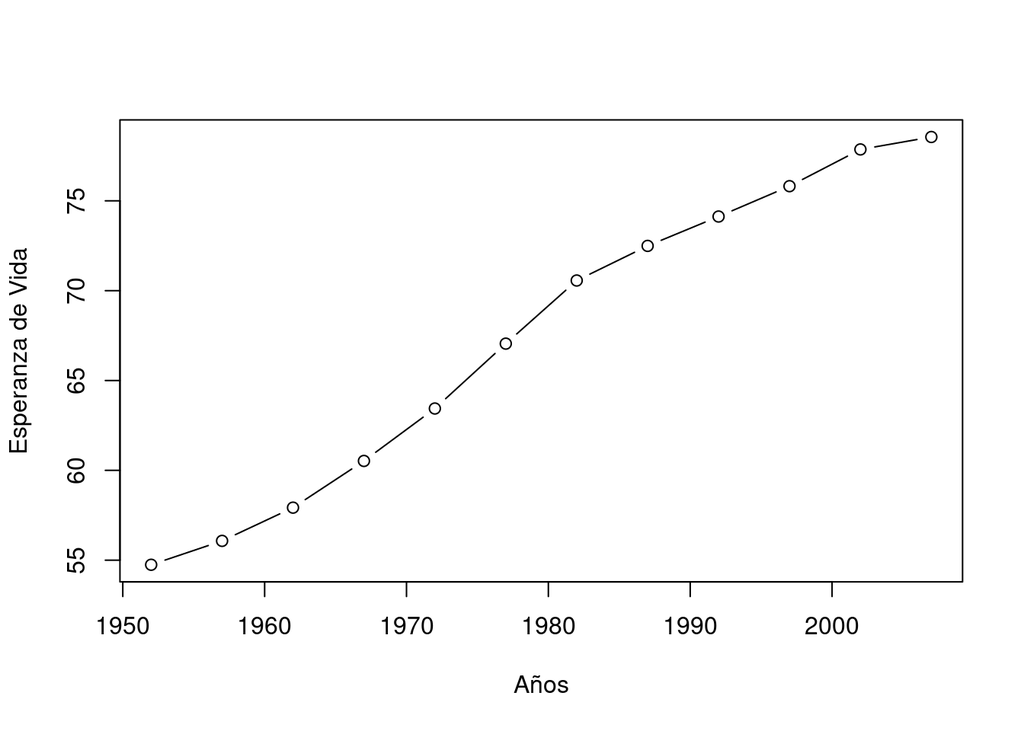

```r
plot(paises_chile$anio,paises_chile$esperanza_de_vida,type='b',
     xlab= 'Años',ylab = 'Esperanza de Vida')
```

7- ¿Cuál es la esperanza de vida en Chile al año 2007?

**Código**

```r
paises_chile[paises_chile$anio == 2007,]$esperanza_de_vida
```

```
[1] 78.553
```

8- ¿Cómo es la esperanza de vida en Chile en comparación con Argentina para el año 2007?

**Código**

```r
paises[paises$pais %in% c('Chile','Argentina') & paises$anio == 2007,c(1,4)]
```

```
         pais esperanza_de_vida
60  Argentina            75.320
288     Chile            78.553
```

9- Respecto al objeto “atmosfera”, grafique los puntos de longitud vs latitud.

**Código**

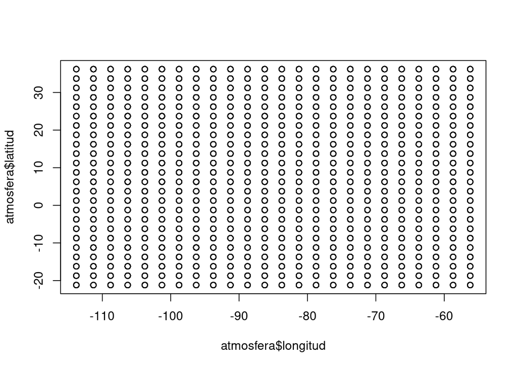

```r
plot(atmosfera$longitud,atmosfera$latitud)
```

10- Respecto al objeto “atmosfera”, si es necesario transforme la variable “temperatura” a gardos celsius.

**Código**

```r
atmosfera$temperatura <- atmosfera$temperatura -273.15
```

**Código**

```r
#temperatura a °Celcisu

clima$temperatura <- (clima$temperatura-32)*5/9
aggregate(clima['temperatura'],by = list(origen = clima$origen),mean,na.rm = TRUE)
```

```
  origen temperatura
1    EWR    13.08142
2    JFK    12.48453
3    LGA    13.20145
```

12- Respecto al objeto clima, ¿en qué meses se dan temperatura menores a -7°C?

**Código**

```r
unique(clima[clima$temperatura < -7,]$mes)
```

```
[1]  1  2 NA 12  5
```

**Código**

```r
clima_selec <- clima[clima$mes %in% 1:2,c('origen','anio','mes','dia','hora','temperatura')]
write_csv2(clima_selec,'../data/clima_seleccion.csv')
```